# Final_Project_Revised

InyeobKim

5/21/2019

## 1 Preparing data

#### 1.1 Introduction

The problem to be solved in this study is to determine whether the gpa can somehow be predicted with certain predictors. Sample data of 61 observations from students is collected: hours of studying on each day(study_hour), type of resource they use the most when studying(resource_type), an average number of times they see TA during a week(freq_TA), hours of sleep on each day(sleep_hour), and whether they are currently in a relationship with other person(relationship). Note that the src_type is categorized into 3 types of textbook, lecture_note and internet. This data is collected completely randomly and independently from the survey using free google survey form. Although the size of the sample data is small to build the most accurate model, we will still be building a model and kind of get the idea of what model parameters are useful for a prediction of y and what are not.

#### 1.1 Load necessary libraries and data

*Attributes:*

**time_stamp**: Column to be removed

**email**: Column to be removed

**study_hour**: Hours of study each day(continuous)

**resource_type**: Type of resource students use the most when studying(textbook, leture_note, internet)(categorical)

**freq_TA**: Average number of times students visit TA during a week(continuous)

**sleep_hour**: Hours of sleep each day(continous)

**relationship**: Whether students are in a relationship with others(continous)

#### 1.2 Missing values

Properly informed with missing data is very significant, because they indicate how much we do not know about the data set. Additionally, many models can break down when missing values are involved, so certain rows with missing data should be either removed or values need to be estimated with appropriate method.

```r
sum(is.na(tab))
```

```
## [1] 0
```

Fortunately, there were no missing values in the data set.

#### 1.3 Reformating dataset

Tidying the data set is necesary for a better data exploring.

```r
tidy_tab <- tab %>%
  # filtering gpa less than 4.0
  filter(gpa <= 4.0) %>%
  # dropping unnecessary columns
  select(-time_stamp,  -email) %>%
  # making two dummy variables for resource_type using fastDummies package
  fastDummies::dummy_cols(remove_first_dummy = TRUE) %>%
  select(-resource_type)

names(tidy_tab)[6] <- "r1"
names(tidy_tab)[7] <- "r2"
```

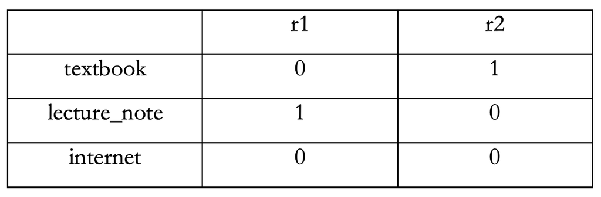

#### 1.4 Visual plots of variables

###### Gpa by study_hour and sleep_hour

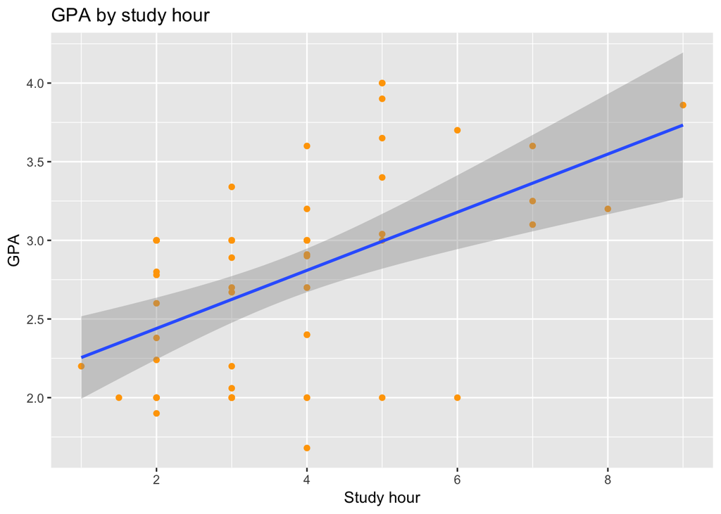

```r
tidy_tab %>%
  ggplot(aes(x=study_hour, y=gpa)) +
  geom_point(color = "orange") +
  geom_smooth(method = lm) +
  labs(title = "GPA by study hour",
       x = "Study hour",
       y = "GPA") +
  scale_x_continuous(breaks = seq(0, 10, 2))
```

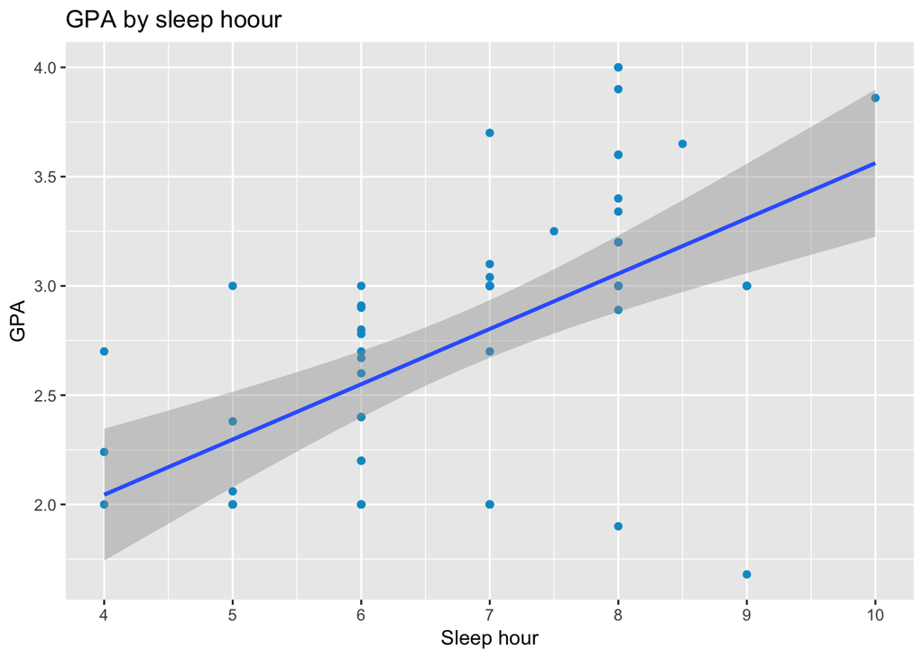

```r
tidy_tab %>%
  ggplot(aes(x=sleep_hour, y=gpa)) +
  geom_point(color = "deepskyblue3") +
  geom_smooth(method = lm) +
  labs(title = "GPA by sleep hoour",
       x = "Sleep hour",
       y = "GPA") +
  scale_x_continuous(breaks = seq(0, 10, 1))
```

It seems there is some linear relationship between GPA and sleep_hour and study_hour with some outliers. Removing those weird values will definitely increase the accuracy of the model.

```r
# removing weird values
useless_rows1 <- which(tidy_tab$study_hour >= 4 & tidy_tab$gpa <= 2.0)
useless_rows2 <- which(tidy_tab$sleep_hour >= 6.5 & tidy_tab$gpa <= 2.5)

# there are some overlaying data, so you must use union function in order not to remove any other data
useless_rows <- union(useless_rows1, useless_rows2)

new_tidy_tab <- tidy_tab[-useless_rows,]
```

We cleaned up the data by dropping certain useless rows.

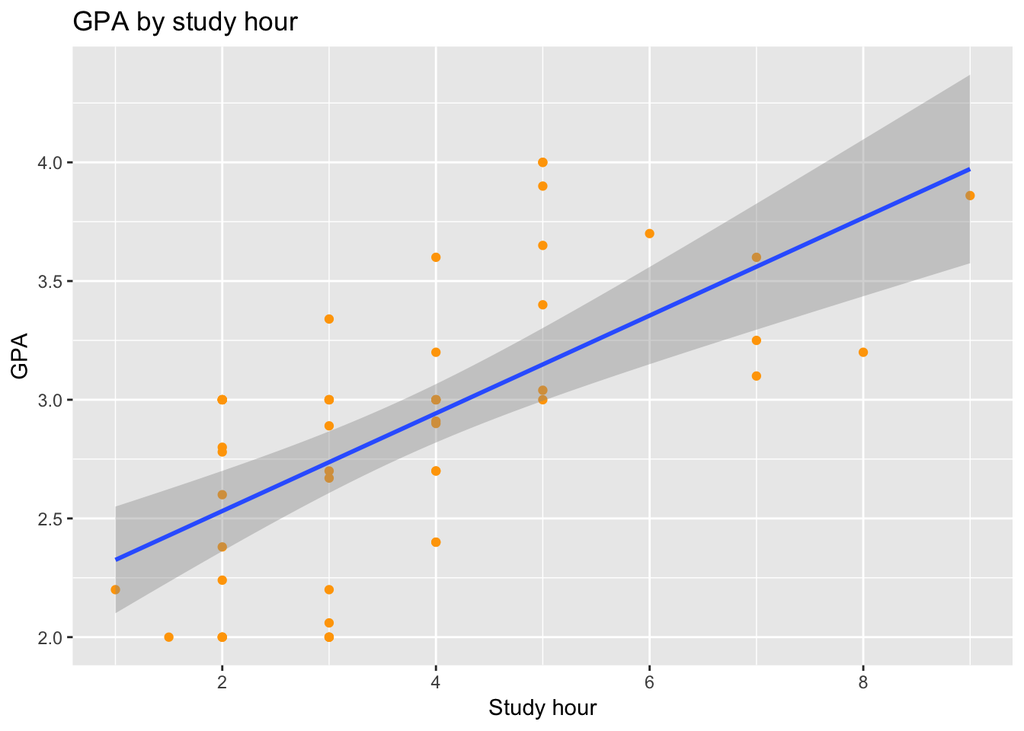

```r
# checking the plot again
 new_tidy_tab %>%
  ggplot(aes(x=study_hour, y=gpa)) +
  geom_point(color = "orange") +
  geom_smooth(method = lm) +
  labs(title = "GPA by study hour",
       x = "Study hour",
       y = "GPA") +
  scale_x_continuous(breaks = seq(0, 10, 2))
```

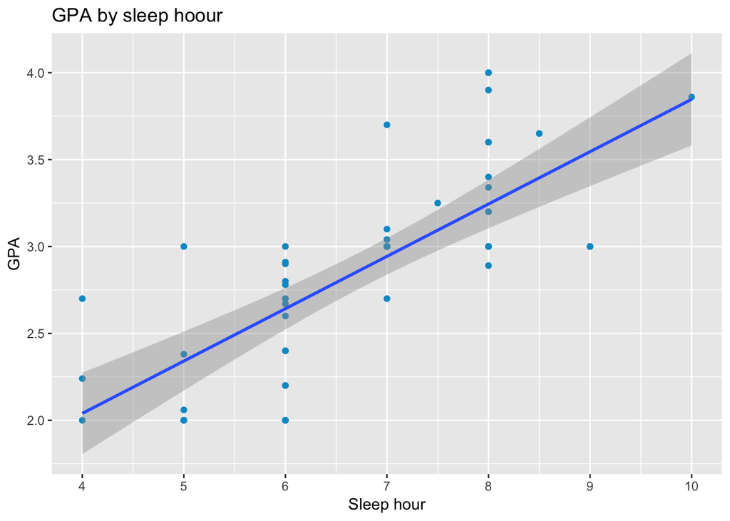

```r
new_tidy_tab %>%
  ggplot(aes(x=sleep_hour, y=gpa)) +
  geom_point(color = "deepskyblue3") +
  geom_smooth(method = lm) +
  labs(title = "GPA by sleep hoour",
       x = "Sleep hour",
       y = "GPA") +
  scale_x_continuous(breaks = seq(0, 10, 1))
```

Plots are much better now!!

#### 1.5 Data scaling

Before we start working on building a model, since there are several data that have different scales, we will standardize the data for better accuracy.

```r
# Could not find the better way to standardize attributes
std_tab <- new_tidy_tab %>%
  mutate(mean_study_hour = mean(study_hour)) %>%
  mutate(sd_study_hour = sd(study_hour)) %>%
  mutate(mean_freq_TA = mean(freq_TA)) %>%
  mutate(sd_freq_TA = sd(freq_TA)) %>%
  mutate(mean_sleep_hour = mean(sleep_hour)) %>%
  mutate(sd_sleep_hour = sd(sleep_hour)) %>%
  mutate(mean_gpa = mean(gpa)) %>%
  mutate(sd_gpa = sd(gpa)) %>%
  mutate(std_study_hour = (study_hour - mean_study_hour) / sd_study_hour) %>%
  mutate(std_freq_TA = (freq_TA - mean_freq_TA) / sd_freq_TA) %>%
  mutate(std_sleep_hour = (sleep_hour - mean_sleep_hour) / sd_sleep_hour) %>%
  mutate(std_gpa = (gpa - mean_gpa) / sd_gpa) %>%
  select(std_gpa, std_study_hour, r1, r2, std_freq_TA, std_sleep_hour, relationship)

names(std_tab)[1] <- "gpa"
names(std_tab)[2] <- "study_hour"
names(std_tab)[5] <- "freq_TA"
names(std_tab)[6] <- "sleep_hour"
```

## 2 Analysis

#### 2.1 Correlation between predictors

```r
library("PerformanceAnalytics")
```

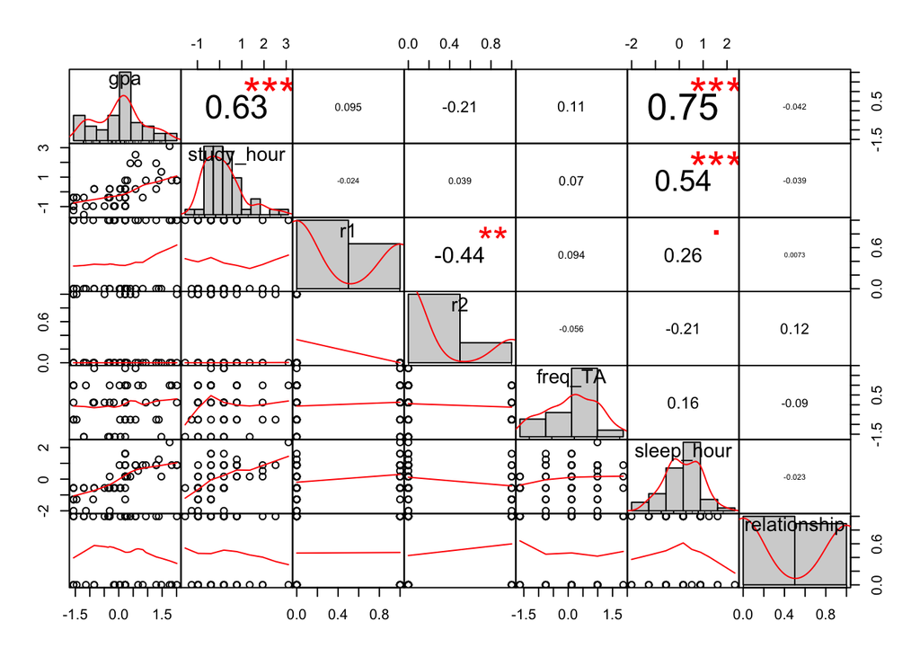

```r
chart.Correlation(std_tab, histogram = TRUE)
```

**Each significance level is associated to symbol**

*p-values*

**0.001** <=> ***

**0.01** <=> **

**0.05** <=> *

**0.1** <=> **.**

```r
mat <- cor(std_tab)
mat
```

```
##                      gpa  study_hour           r1          r2     freq_TA
## gpa           1.00000000  0.63189697  0.095129441 -0.21462097  0.11035273
## study_hour    0.63189697  1.00000000 -0.024166387  0.03874066  0.07032984
## r1            0.09512944 -0.02416639  1.000000000 -0.43826153  0.09440596
## r2           -0.21462097  0.03874066 -0.438261532  1.00000000 -0.05629184
## freq_TA       0.11035273  0.07032984  0.094405965 -0.05629184  1.00000000
## sleep_hour    0.74541636  0.53768206  0.260188514 -0.20644075  0.16276840
## relationship -0.04245473 -0.03876508  0.007290148  0.12098368 -0.08998161
##               sleep_hour relationship
## gpa           0.74541636 -0.042454733
## study_hour    0.53768206 -0.038765075
## r1            0.26018851  0.007290148
## r2           -0.20644075  0.120983676
## freq_TA       0.16276840 -0.089981609
## sleep_hour    1.00000000 -0.023128355
## relationship -0.02312835  1.000000000
```

This table shows more accurate correlation numerically between variables. Like we saw in the above example, the correlation between study_hour and gpa was 0.63. Here, it says 0.6318967(more accurate).The table contains the Pearson correlation coefficients and test results. Notice that the correlation in the main diagonal are all equal to 1. This is because a variable is always perfectly correlated with itself. However, we cannot identify p-values in this table.

#### 2.2 Building a multiple regression model

Now, we saw the correlation between the variables and its significance, let’s plunge into building a multivariate linear regression model using this data sample. The model that we are looking for will be,

###### $\hat{y}$ = $b_{0}$ + $b_{1}$ * study_hour + $b_{2}$ * r1 + $b_{3}$ * r2 + $b_{4}$ * freq_TA + $b_{5}$ * sleep_hour + $b_{6}$ * relationship

```r
model1 <- lm(gpa ~ study_hour + r1 + r2 + freq_TA + sleep_hour + relationship, data = std_tab)
summary(model1)
```

```
##
## Call:
## lm(formula = gpa ~ study_hour + r1 + r2 + freq_TA + sleep_hour +
##     relationship, data = std_tab)
##
## Residuals:
##      Min       1Q   Median       3Q      Max
## -1.06018 -0.50157 -0.02282  0.31532  1.45770
##
## Coefficients:
##               Estimate Std. Error t value Pr(>|t|)
## (Intercept)   0.174836   0.156761   1.115  0.27051
## study_hour    0.332914   0.105847   3.145  0.00291 **
## r1           -0.230984   0.201964  -1.144  0.25867
## r2           -0.383016   0.233561  -1.640  0.10785
## freq_TA      -0.002749   0.088439  -0.031  0.97534
## sleep_hour    0.563214   0.110927   5.077 6.78e-06 ***
## relationship  0.007222   0.174741   0.041  0.96721
## ---
## Signif. codes:  0 '***' 0.001 '**' 0.01 '*' 0.05 '.' 0.1 ' ' 1
##
## Residual standard error: 0.6257 on 46 degrees of freedom
## Multiple R-squared:  0.6536, Adjusted R-squared:  0.6084
## F-statistic: 14.47 on 6 and 46 DF,  p-value: 3.441e-09
```

The value of Adj R-sq is 0.6084, which is ok in this case. This means 60.85% of y-value can be predicted from study_hour, r1, r2, freq_TA, sleep_hour and relationship predictors. The reason why we want to focus on Adj R-Sq instead of R-Square is that each of the predictors comes with the cost of degree of freedom, not counting intercept. You can see that the df value of the whole model above is 6, which implies all the predictors. Let’s say we add a 7 th predictor. Then the R-sq value will probably go up, but that does not take into the account that we are adding another degree of freedom. That will adjust our model if we add extra predictor, degrees of freedom 7, and the AdjRsq will yield a result by taking 7 th degree of freedom into account.

Now we are ready to analyze the overall f-test. Null hypothesis and the alternative hypothesis will be the following.

$H_{0}$: $b_{1}$ = $b_{2}$ = $b_{3}$ = $b_{4}$ = $b_{5}$ = $b_{6}$ = 0

$H_{a}$: At least one of $b_{1}$, $b_{2}$, $b_{3}$, $b_{4}$, $b_{5}$ and $b_{6}$ is not 0.

(At least one of them is useful in predicting y, but we don’t necessarily know which one is)

Assuming alpha is 0.05, we can see that the p-value is less alpha from the table above. We can go ahead and reject the null hypothesis. We can conclude that the alternative hypothesis is correct, and at least one of $b_{1}$, $b_{2}$, $b_{3}$, $b_{4}$, $b_{5}$ and $b_{6}$ is useful in predicting y.

From the result above, we know that only study_hour and sleep_hour are useful in predicting y, we are going to conduct a partial f-test omitting these predictors.

The Null hypothesis and alternative hypothesis will be the following.

$H_{0}$: $b_{2}$ = $b_{3}$ = $b_{4}$ = $b_{6}$ = 0

$H_{a}$: At least one of $b_{2}$, $b_{3}$, $b_{4}$ and $b_{6}$ is not 0.

(At least one of them is useful in predicting y, but we don’t necessarily know which one is)

```r
test <- lm(gpa ~ r1 + r2 + freq_TA + relationship, data = std_tab)
summary(test)
```

```
##
## Call:
## lm(formula = gpa ~ r1 + r2 + freq_TA + relationship, data = std_tab)
##
## Residuals:
##      Min       1Q   Median       3Q      Max
## -1.77325 -0.98581  0.08633  0.58569  2.30255
##
## Coefficients:
##              Estimate Std. Error t value Pr(>|t|)
## (Intercept)   0.12585    0.25254   0.498    0.621
## r1           -0.01330    0.31783  -0.042    0.967
## r2           -0.49937    0.37287  -1.339    0.187
## freq_TA       0.09837    0.14147   0.695    0.490
## relationship -0.01593    0.28212  -0.056    0.955
##
## Residual standard error: 1.011 on 48 degrees of freedom
## Multiple R-squared:  0.05585,    Adjusted R-squared:  -0.02282
## F-statistic: 0.7099 on 4 and 48 DF,  p-value: 0.5892
```

Assuming the alpha is still 0.05, the p-value is larger than the alpha, so we will fail to reject the null hypothesis. This means that we can say that b2, b3, b4 and b6 are equal to 0. So, the ultimate model that we can actually end up using for the data is just the equation with b2, b3, b4 and b6 omitted.

Let’s compare these two model with anova test.

$H_{0}$: Models do not significantly differ

$H_{a}$: Model 1(with all predictors) is significantly better

```r
model2 <- lm(gpa ~ study_hour + sleep_hour, data = std_tab)
anova(model2, model1)
```

```
## Analysis of Variance Table
##
## Model 1: gpa ~ study_hour + sleep_hour
## Model 2: gpa ~ study_hour + r1 + r2 + freq_TA + sleep_hour + relationship
##   Res.Df    RSS Df Sum of Sq      F Pr(>F)
## 1     50 19.200
## 2     46 18.012  4    1.1881 0.7586 0.5576
```

Based on the p-value of 0.5576, we fail to reject the null hypothesis and conclude that we do not have evidence to believe that the model1 is significantly better. We can decide that it is not necessary to include any other predictors except study_hour and sleep_hour.

###### $\hat{y}$ = $b_{0}$ + $b_{1}$ * study_hour + $b_{5}$ * sleep_hour

We can use the model above for estimating as our estimator regression line.

#### 2.3 Assumptions for linear regression

Before we wrap up with the result, we need to check whether the assumptions and conditions for multiple linear regression are satisfied or not. Since the value we are predicting is gpa, which is a continuous value, there is nothing wrong with using linear regression method. Additionally, the data we are modeling meets “iid” condition, which means the error(residual) terms are independent from one another and identically distributed. Let’s take a look at the plots blow.

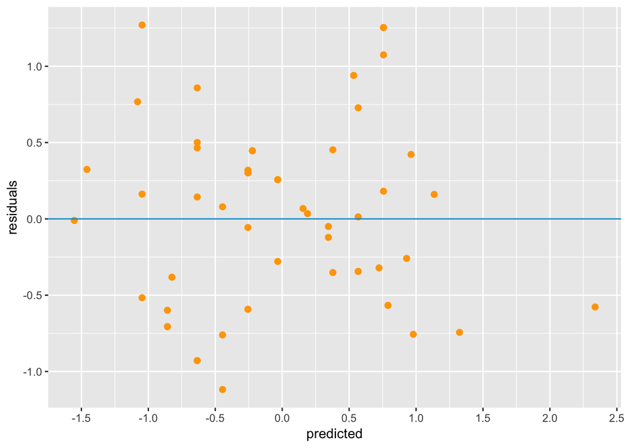

```r
# select our data of interest
new_tab <- std_tab %>%
  select(gpa, study_hour, sleep_hour)

# obtain predicted and residual values using model2 above
new_tab$predicted <- predict(model2)
new_tab$residuals <- residuals(model2)

# plotting residual
new_tab %>%
  ggplot(aes(x=predicted, y=residuals)) +
  geom_point(size = 2, color = "orange") +
  geom_hline(yintercept = 0, color = "deepskyblue3", type = "dashed") +
  scale_x_continuous(breaks = seq(-3, 3, 0.5)) +
  scale_y_continuous(breaks = seq(-3, 3, 0.5))
```

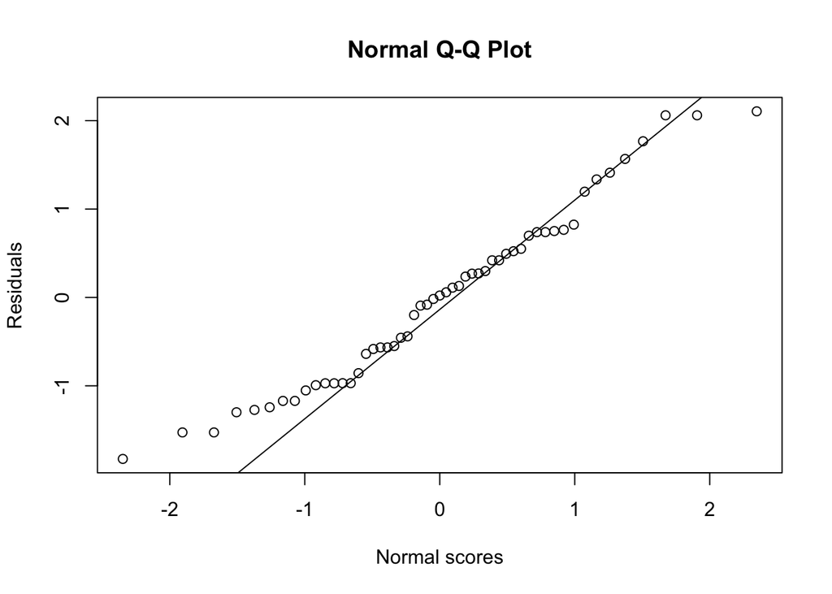

```r
model2.stdres <- rstandard(model2)
qqnorm(model2.stdres,
       ylab = "Residuals",
       xlab = "Normal scores")
qqline(model2.stdres)
```

If we see the bottom Normal Q-Q plot, the residual seems normally distributed with a mean 0, which meets the assumption for linear regression. Additionally, if we take a look at the top scatter plot of residual with respect to predicted value, it is forming a cloud pattern, which seems to be perfectly fine.

#### 2.4 Limitation of the study

Although, I could have done a study with existing dataset, but I wanted to some research on my own using my own data that I collected, however this had a tradeoff. Eventually, the model looks fine, but there are some critical limitations of the study. First of all, the sample size was too small. I had some difficulty in collecting data from students, because not all students answered honestly and carefully. I had to clean up this small dataset, and this made the data set even smaller. Furthermore, the pool of the dataset is only from students who are currently attending Maryland University who are majoring in Computer Science. This is also a huge limitation, because the results may vary depending on the universities and the majors.